# Principal component analysis

Romanova

20 октября 2018 г

Данные INITIAL. Собрали разных людей, измерили у них различные показатели состояния зубов: воспаления десны вокруг зуба (гингивитные индексы DGI, KGI, MGI) и налет на зубах (бляшечный индекс PLI).

Чтобы немного лучше представлять, что из себя представляют данные, взглянем на корреляционную матрицу

```r
cor(initial.active)
```

```
##           DGI       KGI       MFI       PLI
## DGI 1.0000000 0.8019598 0.2258965 0.3346485
## KGI 0.8019598 1.0000000 0.1864334 0.3048980
## MFI 0.2258965 0.1864334 1.0000000 0.5493344
## PLI 0.3346485 0.3048980 0.5493344 1.0000000
```

В описании данных было сказано, что DGI и KGI суть одна и та же характеристика, измеренная разными врачами. Действительно, эти признаки сильно коррелированы. Корреляция с третьим признаком, отвечающим за воспаление десны – невысокая (около 0.2).

В пакете ade4 анализ главных компонент осуществляет функция dudi.pca:

#### dudi.pca(df, row.w = rep(1, nrow(df))/nrow(df), col.w = rep(1, ncol(df)), center = TRUE, scale = TRUE, scannf = TRUE, nf = 2)

### Arguments

df a data frame with n rows (individuals) and p columns (numeric variables)

row.w  
an optional row weights (by default, uniform row weights)

col.w  
an optional column weights (by default, unit column weights)

center  
a logical or numeric value, centring option if TRUE, centring by the mean if FALSE no centring if a numeric vector, its length must be equal to the number of columns of the data frame df and gives the decentring

scale  
a logical value indicating whether the column vectors should be normed for the row.w weighting

scannf  
a logical value indicating whether the screeplot should be displayed

nf  
if scannf FALSE, an integer indicating the number of kept axes

### Value

Returns a list of classes pca and dudi (see dudi) containing the used information for computing the principal component analysis :

tab the data frame to be analyzed depending of the transformation arguments (center and scale)

cw  
the column weights

lw  
the row weights

eig the eigenvalues $\lambda_{i}$

rank  
the rank of the analyzed matrice

nf  
the number of kept factors

c1  
the column normed scores i.e. the principal axes $U_{i}$

l1  
the row normed scores $V_{i}$

co  
the column coordinates $F_{i}$

li  
the row coordinates i.e. the principal components $Z_{i}$

call  
the call function

cent  
the p vector containing the means for variables (Note that if center = F, the vector contains p 0)

norm  
the p vector containing the standard deviations for variables i.e. the root of the sum of squares deviations of the values from their means divided by n (Note that if norm = F, the vector contains p 1)

Вычисляем PCA при помощи функции dudi.pca пакета ade4.

```r
res.pca<-dudi.pca(initial.active, nf = 4, scannf = FALSE)
```

Величина собственных чисел корреляционной матрицы (данные стандартизированы) показывает, какой процент от общего разброса объясняет каждая главная компонента. Собственные числа ($\lambda_{i}$):

```r
eig.val <- get_eigenvalue(res.pca)
eig.val
```

```
##       eigenvalue variance.percent cumulative.variance.percent
## Dim.1  2.2212681        55.531701                    55.53170
## Dim.2  1.1426464        28.566161                    84.09786
## Dim.3  0.4391182        10.977955                    95.07582
## Dim.4  0.1969673         4.924182                   100.00000
```

Первые два новых признака более информативны, чем старые (значение > 1). 84% разброса объясняется первыми двумя главными компонентами. 95% – тремя.

В виде графика:

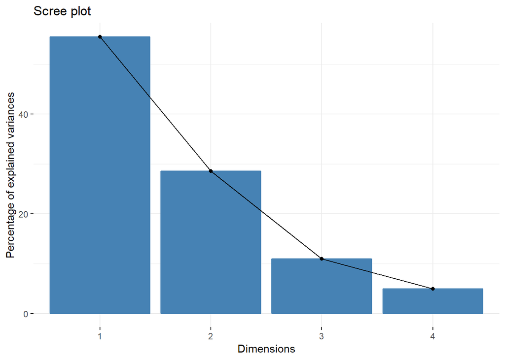

```r
fviz_eig(res.pca)
```

Собственные векторы ($U_{i}$):

```r
res.pca$c1
```

```
##           CS1        CS2         CS3          CS4
## DGI 0.5632602  0.4103097 -0.08103200  0.712613303
## KGI 0.5485333  0.4517531 -0.06257569 -0.700795671
## MFI 0.3998444 -0.6265679 -0.66825117 -0.031264137
## PLI 0.4711408 -0.4847449  0.73685716 -0.009500602
```

Из таблицы видно, что в первую главную компоненту все переменные вносят существенный вклад, причем все переменные входят с одним знаком. Эту компоненту можно интерпретировать как общее состояние зубов (чем больше значение, тем хуже состояние зубов). Вторая главная компонента показывает разницу между похожими показателями DGI и KGI и показателями MGI и PLI. Третья компонента суть разница между уровнем воспаления десен и зубным налетом, причем за показатель уровня воспаления берется признак MGI. Четвертая компонента (от которой вполне можно избавиться) по смыслу довольно странная и в лоб интерпретируется как разница между оценкой воспаления одним специалистом и оценкой воспаления другим специалистом.

Матрица факторных весов (координаты признаков) $\mathbb{F}=(F_{i})$:

```r
res.pca$co
```

```
##         Comp1      Comp2       Comp3        Comp4
## DGI 0.8394784  0.4385991 -0.05369666  0.316264896
## KGI 0.8175296  0.4828999 -0.04146641 -0.311020112
## MFI 0.5959249 -0.6697676 -0.44282328 -0.013875336
## PLI 0.7021844 -0.5181664  0.48828572 -0.004216462
```

На двумерной диаграмме факторных весов можно наблюдать, как связаны первые главные компоненты и старые признаки. При помощи этого графика можно интерпретировать первые две главные компоненты. Длины векторов, соответствующих старым признакам, пропорциональны тому, насколько каждый старый признак описывается первыми двумя главными компонентами. Эти векторы раскрашены в соответствии с параметром “contrib”. Величина этого параметра показывает, насколько большой вклад вносит переменная в анализ главных компонент.

Пусть $X_{i}$ – $i$-й старый признак (мы его предварительно стандартизировали), $d=p$. Тогда вклад $i$-го признака в $j$-ю главную компоненту вычисляется следующим образом:
$$\mathrm{contrib}(X_{i},V_{j})=\frac{\cos^{2}(X_{i},V_{j})*100}{\sum_{k=1}^{d}\cos^{2}(X_{k},V_{j})}
=
\frac{f_{ij}^{2}*100}{||F_{j}||^{2}}
=
\frac{f_{ij}^{2}*100}{\lambda_{j}}.$$

Вклад $i$-й переменной в первые две главные компоненты (именно он и отображается на графике цветом) вычисляется по формуле
$$\mathrm{Contrib}(X_{i})
=
\frac
{\lambda_{1}\mathrm{contrib}(X_{i},V_{1})
+
\lambda_{2}\mathrm{contrib}(X_{i},V_{2})}
{\lambda_{1}+\lambda_{2}}
=
\frac
{100(f_{i1}^{2}+f_{i2}^{2})}{\lambda_{1}+\lambda_{2}}.$$

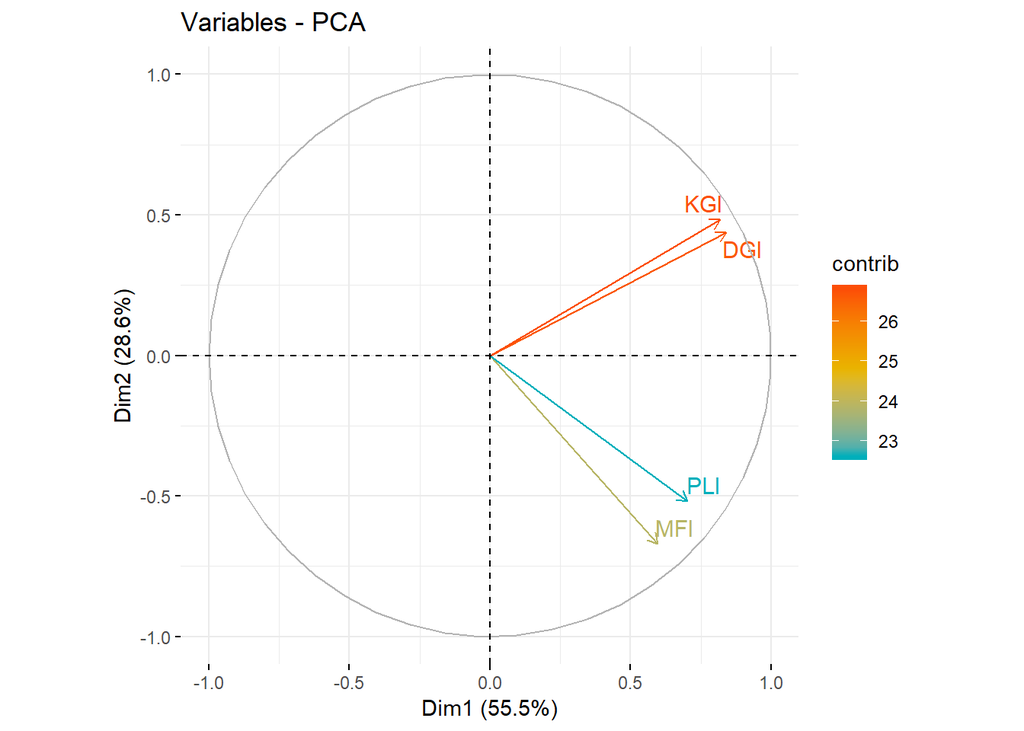

```r
fviz_pca_var(res.pca,
             col.var = "contrib",
             gradient.cols = c("#00AFBB", "#E7B800", "#FC4E07"),
             repel = TRUE
             )
```

В данном случае мы уже интерпретировали главные компоненты при помощи значений собственных векторов $U_{i}$, информация о первых двух компонентах, которую можно извлечь из настоящего графика, не противоречит полученной ранее информации: видно, что в первую компоненту все переменные входят с одним знаком, а во второй компоненте по разные стороны находятся признаки KGI, DGI и MGI, PLI. Переменные KGI и DGI лучше всех описываются первыми главными компонентами и вносят наибольший вклад в анализ главных компонент. Отметим, однако, что, хоть раскраска и показывает нам верную иерархию вклада старых признаков, но разница между вкладами на самом деле не очень большая (признак PLI вносит не намного меньший вклад, чем, наример, KGI).

Следующий график (биплот) изображает наблюдения в системе координат первых двух главных компонент. На нем можно увидеть неоднородность данных (если она есть) и аутлаеров. Также можно указать направления старых признаков.

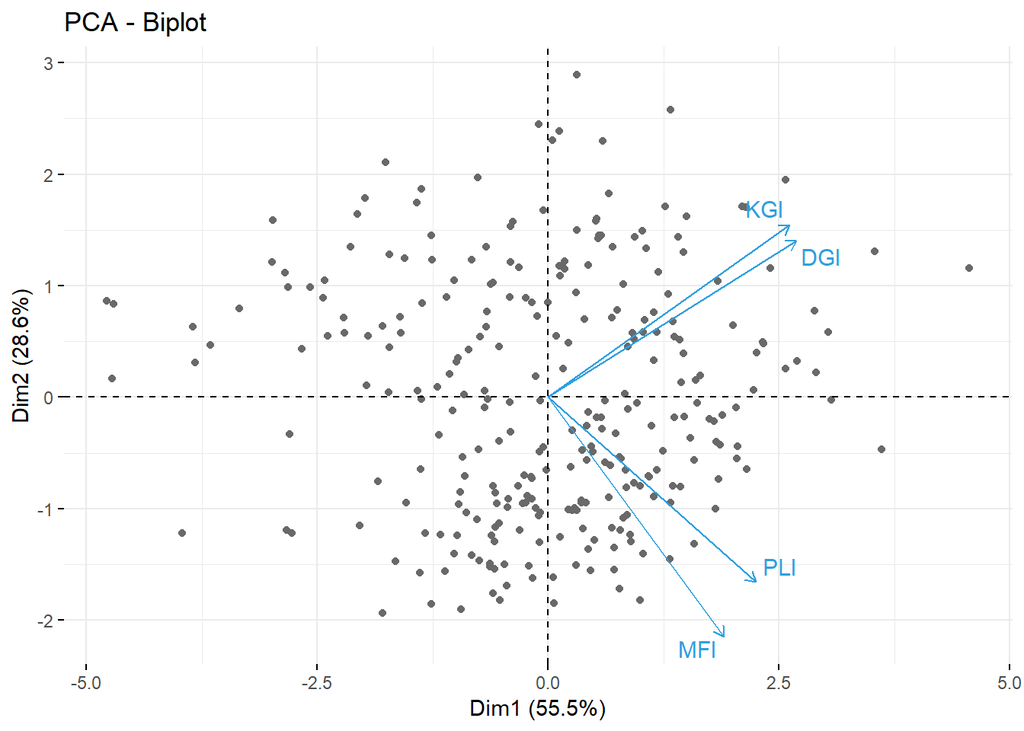

```r
fviz_pca_biplot(res.pca, repel = TRUE,
                col.var = "#2E9FDF",
                col.ind = "#696969",
                label = "var"
                )
```

В данном случае нет неоднородности, которая бы бросалась в глаза. Но попробуем раскрасить наблюдения в соответствии с доступными качественными признаками, чтобы это проверить.

Биплот по группам женщины/мужчины (неоднородности не выявлено):

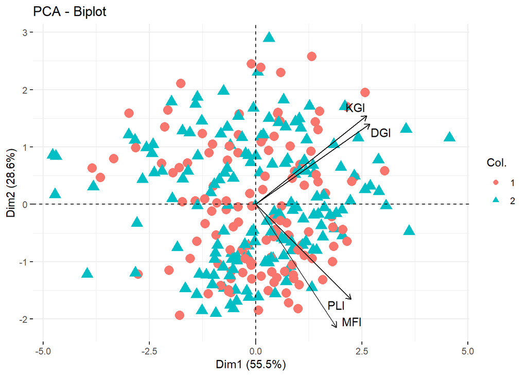

```r
fviz_pca_biplot(res.pca, repel = TRUE,
                col.var = "black",
                 col.ind = as.factor(add.inf$sex),
                label = "var",
                pointsize = as.factor(add.inf$sex)
                )
```

По группам по возрасту:

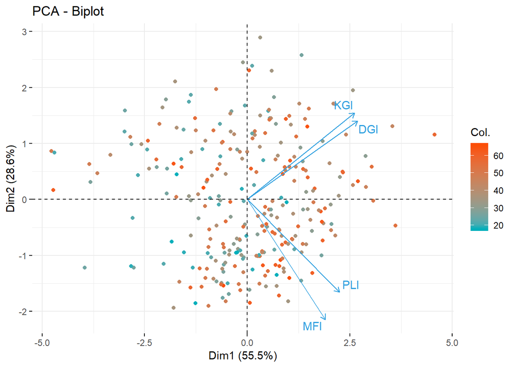

```r
fviz_pca_biplot(res.pca, repel = TRUE,
                col.var = "#2E9FDF",
                 col.ind = add.inf$age,
                label = "var",
                 gradient.cols = c("#00AFBB", "#FC4E07")
                )
```

В градиентном варианте не слишком хорошо видно, есть ли неоднородность, так что создадим группирующую качественную переменную и раскрасим в соответствии с ней.

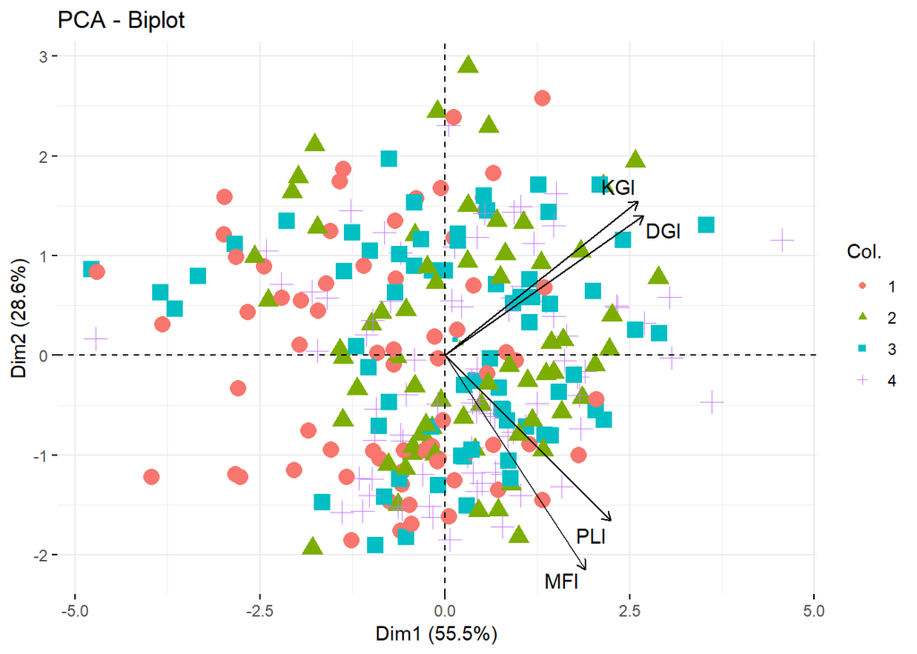

```r
fviz_pca_biplot(res.pca, repel = TRUE,
                col.var = "black",
                 col.ind = as.factor(add.inf$age2),
                label = "var",
                pointsize = as.factor(add.inf$age2)
                )
```

Неоднородности как таковой нет, младшие индивиды сдвинуты немного влево, но форма сохраняется и это больше похоже на “раскраску”, чем на неоднородность. Принимать наиболее далеких индивидов за выбросы здесь тоже рука не поднимается. Поэтому данные оставляем без изменений. Можем провести еще раз анализ главных компонент, задав итоговое количество учитываемых компонент (мы уже знаем, что 2 главные компоненты обеспечивают 84% информации, что довольно прилично).

```r
res.pca<-dudi.pca(initial.active, nf = 2, scannf = FALSE)
```

Матрица $\mathbb{Z}$ главных компонент (координаты индивидов):

```r
res.pca$li[1:6,]
```

```
##        Axis1     Axis2
## 1 -2.9878581 1.2110092
## 2 -1.2665146 1.4523167
## 3  0.1331077 1.0909346
## 4 -4.7768234 0.8607047
## 5 -3.8460197 0.6298448
## 6 -4.7238774 0.1701073
```